# Презентация по лабораторной работе №8

Дисциплина: Архитектура компьютеров и операционные системы

Гусев Степан Андреевич

1032242444@rudn.ru

Российский университет дружбы народов

2026-03-30

# Информация

**Презентация по лабораторной работе №8**

**Автор:** Гусев Степан Андреевич

**Преподаватель:** Кулябов Дмитрий Сергеевич, д.ф.-м.н., профессор кафедры теории вероятностей и кибербезопасности

Российский университет дружбы народов

## Докладчик

- Гусев Степан Андреевич
- Студент программы “Бизнес-информатика”
- Российский университет дружбы народов им. П. Лумумбы
- 1032242444@rudn.ru
- https://github.com/stepagusev

## Цель

Ознакомление с инструментами поиска файлов и фильтрации текстовых данных. Приобретение практических навыков: по управлению процессами (и заданиями), по проверке использования диска и обслуживанию файловых систем.

## Задание

1. Осуществите вход в систему, используя соответствующее имя пользователя.
2. Запишите в файл file.txt названия файлов, содержащихся в каталоге /etc. Допишите в этот же файл названия файлов, содержащихся в вашем домашнем каталоге.
3. Выведите имена всех файлов из file.txt, имеющих расширение .conf, после чего запишите их в новый текстовой файл conf.txt.
4. Определите, какие файлы в вашем домашнем каталоге имеют имена, начинавшиеся с символа c? Предложите несколько вариантов, как это сделать.
5. Выведите на экран (постранично) имена файлов из каталога /etc, начинающиеся с символа h.

## Задание

6. Запустите в фоновом режиме процесс, который будет записывать в файл ~/logfile файлы, имена которых начинаются с log.
7. Удалите файл ~/logfile.
8. Запустите из консоли в фоновом режиме редактор gedit.
9. Определите идентификатор процесса gedit, используя команду ps, конвейер и фильтр grep. Как ещё можно определить идентификатор процесса?
10. Прочтите справку (man) команды kill, после чего используйте её для завершения процесса gedit.
11. Выполните команды df и du, предварительно получив более подробную информацию об этих командах, с помощью команды man.
12. Воспользовавшись справкой команды find, выведите имена всех директорий, имеющихся в вашем домашнем каталоге.

# Выполнение лабораторной работы

## Выполнение лабораторной работы

Вошёл в систему.

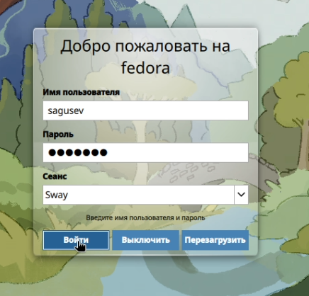

Рисунок 1: Вход в систему

## Выполнение лабораторной работы

Записал в файл file.txt названия файлов, содержащихся в каталоге /etc.

## Выполнение лабораторной работы

Дописал в этот же файл названия файлов, содержащихся в домашнем каталоге.

## Выполнение лабораторной работы

Вывел имена всех файлов из file.txt, имеющих расширение .conf, после чего записал их в новый текстовой файл conf.txt.

## Выполнение лабораторной работы

Определил, какие файлы в домашнем каталоге имеют имена, начинавшиеся с символа ‘c’ двумя способами.

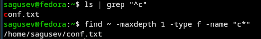

Рисунок 5: Поиск файлов

## Выполнение лабораторной работы

Вывел на экран постранично имена файлов из каталога /etc, начинающиеся с символа ‘h’.

## Выполнение лабораторной работы

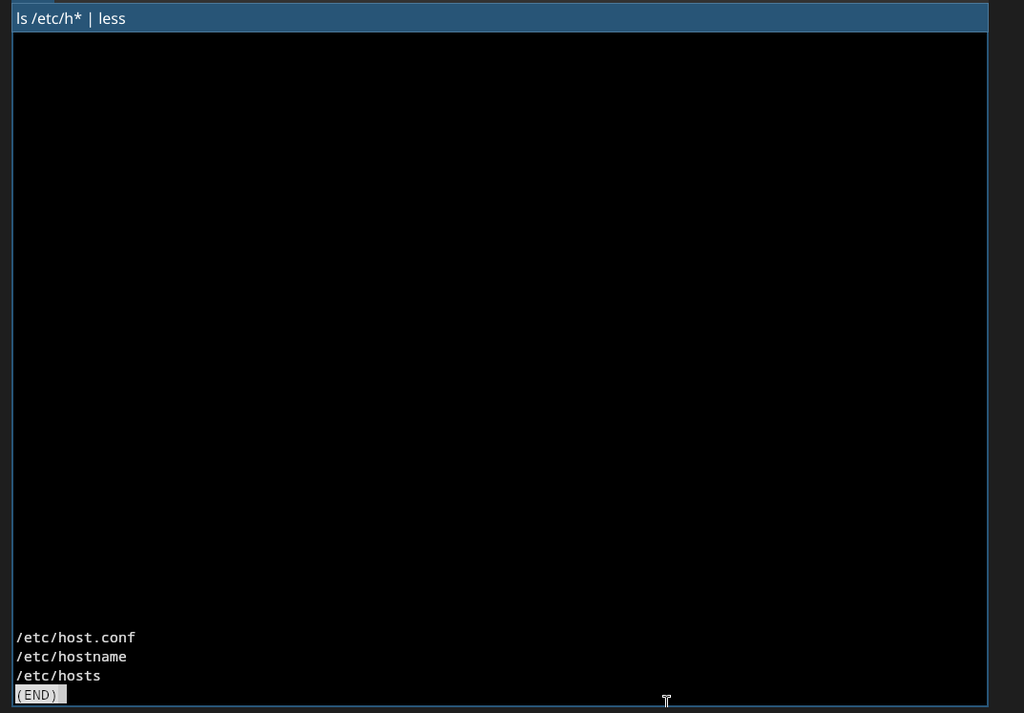

Рисунок 7: Вывод файлов

## Выполнение лабораторной работы

Запустил в фоновом режиме процесс, который записывает в файл ~/logfile файлы, имена которых начинаются с ‘log’.

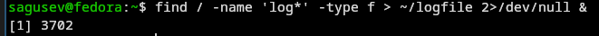

Рисунок 8: Запуск фонового процесса

## Выполнение лабораторной работы

Удалил файл ~/logfile.

## Выполнение лабораторной работы

Запустил из консоли в фоновом режиме редактор nano вместо gedit, т.к. он не установлен.

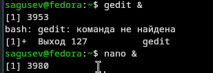

Рисунок 10: Запуск редактора в фоновом режиме

## Выполнение лабораторной работы

Определил идентификатор процесса nano, используя команду ps, конвейер и фильтр grep.

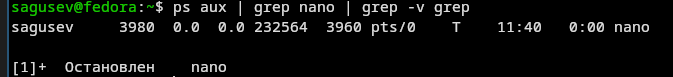

Рисунок 11: Определение идентификатора процесса ps

## Выполнение лабораторной работы

Ещё можно определить идентификатор процесса с помощью команды pgrep.

## Выполнение лабораторной работы

Прочёл справку команды kill.

## Выполнение лабораторной работы

Использовал kill для завершения процесса nano.

## Выполнение лабораторной работы

Получил информацию о df и du, с помощью команды man.

## Выполнение лабораторной работы

Выполнил команду df -h, определив объем свободной памяти на жёстком диске.

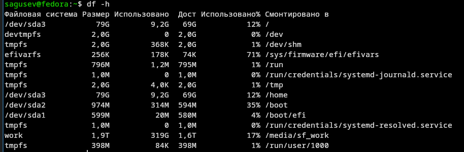

Рисунок 16: df -h

## Выполнение лабораторной работы

Выполнил команду du -sh ~, определив объем домашнего каталога.

## Выполнение лабораторной работы

Прочёл справку команды find.

## Выполнение лабораторной работы

Вывел имена всех директорий, имеющихся в домашнем каталоге с помощью find.

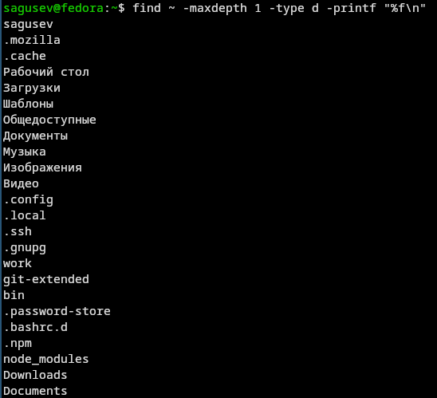

Рисунок 19: Вывод имён директорий

# Выводы

## Выводы

Я ознакомился с инструментами поиска файлов и фильтрации текстовых данных. Я приобрёл практические навыки по управлению процессами (и заданиями), по проверке использования диска и обслуживанию файловых систем.